```python
import numpy as np
import matplotlib.pyplot as plt
from imageio import imread

# Laget for illustrasjon, ikke fullt fungerende
# Bedre, og fungerende, implementasjon i løsningshint 12
class Aritmetisk:

    def _encode(self, sequence, length_of_compression, sequences_nr):

        compression = np.zeros(sequences_nr)

        for j in range(sequences_nr):

            c_i = 1
            start = 0
            for i in range(length_of_compression):
                a_i = int(np.round(sequence[j*length_of_compression + i]))

                start += self.interval[a_i]*c_i
                c_i = self.p[int(a_i)]*c_i
            # Here, a number in the interval should be chosen with the smallest bit-length
            # This code does't do that and is likely therefore defunct
            compression[j] = start
            #print(start, start+c_i)

        return compression

    def encode(self, sequence, length_of_compression):
        # We need the number of sequences to be compressed to be integers
        assert len(sequence)%length_of_compression == 0
        self.length_of_compression = length_of_compression

        sequences_nr = int(len(sequence)/length_of_compression)

        self.p = np.zeros(256)
        for x in sequence:
            self.p[int(np.round(x))] += 1
        self.p = self.p/len(sequence)

        c = np.zeros(256)
        c[0] = 0
        for i in range(len(self.p)):
            c[i] = c[i-1] + self.p[i-1]
        self.interval = {i:c[i] for i in range(len(c)) if self.p[i] != 0}
        #print(self.interval)

        return self._encode(sequence, length_of_compression, sequences_nr)

    def decode(self, sequence):

        decompressed = list()

        for numb in sequence:

            start = 0
            c_i = 1
            for i in range(self.length_of_compression):
                a_i = 0
                for intens in self.interval:
                    if numb >= start+(self.interval[intens]*c_i):
                        a_i = intens
                start += self.interval[a_i]*c_i
                c_i = self.p[a_i]*c_i
                decompressed.append(a_i)

        return decompressed


a = Aritmetisk()
compressed = a.encode([1,2,3,3,2, 6,3,2,5,2], 10)
decomp = a.decode(compressed)
print(compressed, decomp)
```

```
[0.03774632] [1, 2, 3, 3, 2, 6, 3, 2, 5, 2]
```

<- Tilbake til liste over notater

# Litt om forrige forelesning: Kompresjon og koding I

### Det som skal skje:

- Entropi og redundans
- Huffman
- Shannon-Fano
- Aritmetisk
- JPEG: Oblig 2 parafrase

## Å forstå entropi

Ikke tenk termodynamikk, dette er hentet fra kommunikasjonsteknologi!

### Entropi er et mål på hvor mye informasjon en beskjed faktisk inneholder.

Litt intuitivt kan vi spør: Hvilket bilde inneholder mest informasjon?

[figure not shown]

Det er forholdsvis lett å se at Einstein 1 har mindre informasjon enn Einstein 2. I bildebehandling kan vi være matematiske i denne oppfatningen, gjennom entropi.

### Og husk: Informasjon er et matematisk begrep som kvantifiserer hvor overraskende / uventet en melding er

Om du scannet bildet piksel for piksel, hvor overrasket blir du over den neste pikselen du ser?

For hver melding / symbol / intensitet i gjelder dette: $$ \hbox{info}_i = \log_2{\frac{1}{p[i]}}$$

[figure not shown]

### Så nå kan vi regne ut gjennomsnittlig informasjon i en melding / tekst / bilde:

p er normalisert histogram.

[figure not shown]

Og dette kan vi bruke til å uttrykke det vi så i de to bildene helt på starten:

|  | Tegnet-Albert | Albert |
| --- | --- | --- |
| Entropi | 2.866 | 7.5 |

[figure not shown]

### Interessant, men hva skal vi med det?

Entropien vår forteller oss at måten vi representerer den tegnede Albert på er altfor voldsom for hvor lite informasjon den faktisk har i seg. Representasjonen er *redundant*, og vi kan kode symbolene slik at gjennomsnittlig bit-lengde er nærme entropien, UTEN å miste noe informasjon.

## Nytt fagbegrep: Redundans!

Det finnes mange former for redundans, men jeg vil vise 2:

- Intersampel redundans
- Psykovisuell redundans

### Intersampel redundans:

Hva har disse to bildene til felles?

[figure not shown]

Det lilla bildet kunne vært representert som bredde, høyde, lilla, og ingen informasjon ville vært tapt.

### Psykovisuell redundans:

Et av disse bildene er komprimert til en $\frac{1}{8}$ av den andres størrelse. Kan du se hvilket?

[figure not shown]

Hva med nå?

[figure not shown]

JPEG i oblig 2 bruker dette!

# Kompresjonsmetoder

Vi skal snakke om 4 denne gangen:

- Huffman
- Shannon-Fano
- Aritmetisk
- JPEG

Jeg vil også vise at kompresjon ofte er en 3-stegs prosess:

[figure not shown]

Og jeg vil uttrykke hvilket steg vi er på, og også hvilken redundans vi reduserer.

## Huffman: Eksempel

Vi vil redusere *koding redundans*. Alle symbol / intensiteter blir representert med 8 bit i et bilde, men om hele bildet er svart og hvitt, er det overkill å kode det slik.

[figure not shown]

Huffman spesialiserer på å bruke variabel lengde på symboler / intensiteter.

### Eksempel

[figure not shown]

```
[ 526.  687.  564.  723. 1084. 5892. 2633.  179.]
Filstørrelse: 36864.0 bits
```

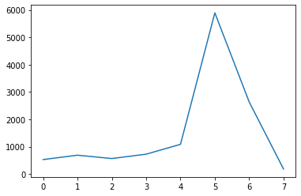

```python
cow = imread("tiny_cow.jpg", as_gray=True)//(2**(8-3))
p = np.zeros(2**3)
for i in cow.ravel():
    p[int(i)] += 1

plt.plot(p)
print(p)

print("Filstørrelse:", np.sum(p*3),"bits")
```

## Steg 1: Gro et tre

[figure not shown]

## Steg 2: Kodebok

| Intensitet | Kode | Bitlengde |
| --- | --- | --- |
| 0 | 10110 | 5 |
| 1 | 10000 | 5 |
| 2 | 10001 | 5 |
| 3 | 1010 | 4 |
| 4 | 1001 | 4 |
| 5 | 0 | 1 |
| 6 | 11 | 2 |
| 7 | 10111 | 5 |

## Shannon-Fano

Veldig likt! Samme kompresjonsteg og reduserer også koding redundans.

### Steg 1: Gro et tre

[figure not shown]

## Steg 2: Kodebok

| Intensitet | Kode | Bitlengde |
| --- | --- | --- |
| 0 | 11110 | 5 |
| 1 | 1101 | 4 |
| 2 | 1110 | 4 |
| 3 | 1100 | 4 |
| 4 | 101 | 3 |
| 5 | 0 | 1 |
| 6 | 100 | 3 |
| 7 | 11111 | 5 |

## Hvem vant?

Ny kodelengde vil bli histogram[i] * bit_lengde_i for hver intensitet:

|  | Representasjonslengde | Bitlengde |
| --- | --- | --- |
| Huffman | 28166.0 bits | 2.292155 |
| Shannon-Fano | 28464.0 bits | 2.316406 |
| Entropi | 27700.7984439388 | 2.254297 |

# Aritmetisk koding

[figure not shown]

Veldig imponerendee teori: En bit-sekvens kan representeres som *ett* desimaltall. Reduserer definitivt *koding redundans*.

## Eksempel

Sekvens: $$ [1,2,3,2,3,3,1,3,1,2] $$

[figure not shown]

```python
sek = [1,2,3,2,3,3,1,3,1,2]
a = Aritmetisk()
compressed = a.encode(sek, len(sek))
reconstruct = a.decode(compressed)
print("Komprimert:",compressed[0])
print("Rekonstruert:", reconstruct)
```

```
Komprimert: 0.1642017024
Rekonstruert: [1, 2, 3, 2, 3, 3, 1, 3, 1, 2]
```

Under var et eksempel på aritmetisk koding som førte til tap, der årsaken muligens er at et ikke-optimalt tall hadde blitt valgt fra intervallet. Man burde ikke velge et vilkårlig tall, man burde ta et tall med minst mulig bit-representasjon.

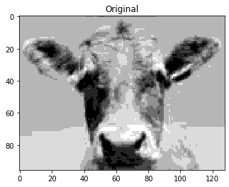

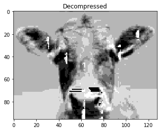

```python
cow_int = cow.astype(int)
compressed = a.encode(cow_int.ravel(), int(cow_int.shape[1]/8))
decomp = a.decode(compressed)

plt.imshow(cow_int, cmap="gray")
plt.title("Original")
plt.figure()
plt.imshow(np.array(decomp).reshape(cow_int.shape), cmap="gray")
plt.title("Decompressed")
None
```

# JPEG: Oblig 2 parafrase

### Steg 1:

Last inn bilde

[figure not shown]

### Steg 2:

Trekk fra 128

### Steg 3:

[figure not shown]

Del opp i 8x8 blokker

[figure not shown]

Påfør 2D DCT på **hver** blokk: $$ F(u,v) = \frac{1}{4} c(u) c(v) \sum_{x=0}^{7} \sum_{y=0}^{7} f(x,y) \cos \bigg({\frac{(2x + 1)u\pi}{16}} \bigg) \cos \bigg({\frac{(2y + 1)v\pi}{16}} \bigg) $$ $$ c(a) = \frac{1}{\sqrt{2}} \hbox{ if a == 0 else 1} $$

[figure not shown]

$ Blokk(u,v) = \frac{1}{4} c(u) c(v) sum \Big($

[figure not shown]

$\Big) $

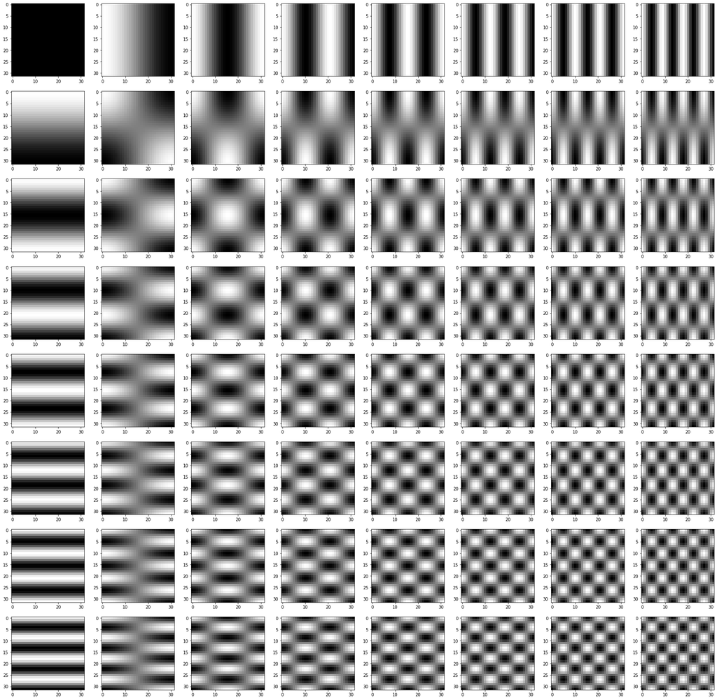

```python
sampling = 32

cosinus = lambda x,u : np.cos( (2*x + 1)*u*np.pi / (sampling+sampling) )
cos_bilde = lambda u, v: [[ cosinus(x,u)*cosinus(y,v) for x in range(sampling)] for y in range(sampling)]

fig = plt.figure(figsize=(30,30))
for u in range(8):
    for v in range(8):
        cos_uv = cos_bilde(u,v)
        fig.add_subplot(8,8,1+(u+v*8))
        plt.imshow(cos_uv, cmap="gray")
plt.show()
```

### Steg 4: Ikke faktisk en del av JPEG-algoritme, men en del av oblig

Rekonstruer med IDCT og +128 Test: Er før og etter lik? Da har du nok gjort det rett

### Steg 5:

[figure not shown]

**Fjerner: Psykovisuell redundans**, i form av høye frekvenser

Del blokkene på qQ og rund av:

[figure not shown]

### Steg 6:

Ting dere IKKE skal gjøre, men som er en del av JPEG:

1. Indeks 0,0 (DC-komponenten) skal tas ut av hver blokk
2. De resterende 63 pikslene i hver blokk skal bli representert mer kompakt
3. DC-komponentene skal også transformeres til mer kompakt
4. De kompakte representasjonene skal entropi-kodes (Huffman, Aritmetisk)

Det DERE skal: Regn ut

1. Entropi
2. Lagringsplass basert på entropi
3. Kompresjonsrate

### Steg 7:

Rekonstruer, og lagre til fil.

Bruk funksjonen på $$ q = [0.1,0.5,2,8,32] $$ Og svar på tekstsvarene!

# Se forelesningen når den kommer ut! Lykke til med oblig :)